# R을 이용한 데이터 전처리와 시각화 기초 코스

Author

waterfirst

[figure not shown]

## 1 Introduction

이 수업은 코딩을 전혀 모르는 사람들을 대상으로 숫자로 된 데이터를 적절히 칼질하여 요리할 수 있도록 하는 것을 목적으로 만들었습니다.

반복적으로 정형화된 데이터를 처리하고 그래프를 그리는 연구원들은 최종적으로는 자신의 결과물을 알기 쉽게 표현하는 것입니다.

이를 위해 tidyverse 패키지 하나만으로 얼마나 쉽게 데이터를 다룰 수 있는지 R의 장점이 무엇인지 알 수 있는 시간이 될 것입니다.

**R 언어 간단 소개**

두명의 뉴질랜드 통계학자가 만듦 : 로버트 젠틀맨(Robert Gentleman)과 로스 이하카(Ross Ihaka)

해들리 위컴에 의해 빅데이터 툴로 발전함 (대표적 : ggplot, tidyverse)

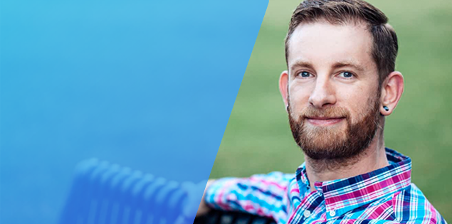

**언어의 특징**

1부터 시작 (다른 언어들은 0부터 시작)

**패키지 설치, 불러오기**

- install.packages(“패키지이름”)
- library(패키지이름)

## 2 강의순서

### 1. R 설치, 기본문법 및 전처리 (1주차)

### 2. 데이터 불러오기, 데이터 시각화 ggplot (2주차)

#### 1. 데이터불러오기

To learn more about **tidyr** see https://tidyr.tidyverse.org/reference/pivot_longer.html/.

#### 2. R의 내장 데이터에서 불러오기

```
data() , help("AirPassengers")
```

https://vincentarelbundock.github.io/Rdatasets/datasets.html

#### 3. 외장데이터 불러오기 (package 설치, library로 불러오기)

```
gapminder : 세계 여러 국가의 인구, 경제, 건강 등의 데이터를 포함
```

#### 4. 클릭보드(엑셀)에서 붙여넣기

[output not shown]

#### 5. csv 파일에서 불러오기

#### 6. 엑셀파일 불러오기

https://readxl.tidyverse.org/

### 3. 데이터 시각화

[ggplot 갤러리] [The R Graph Gallery – Help and inspiration for R charts (r-graph-gallery.com)](https://r-graph-gallery.com/)

[한국 R 사용자회 – 챗GPT 데이터 시각화 (r2bit.com)] https://r2bit.com/bitSlide/chatgpt_viz_202406.html#/데이터-시각화

[참고 자료] https://waterfirst.quarto.pub/r_course/#/title-slide

[참고 자료] https://rstudio.github.io/cheatsheets/html/data-visualization.html

### 4. 머신러닝 (회귀/분류) (4주차)

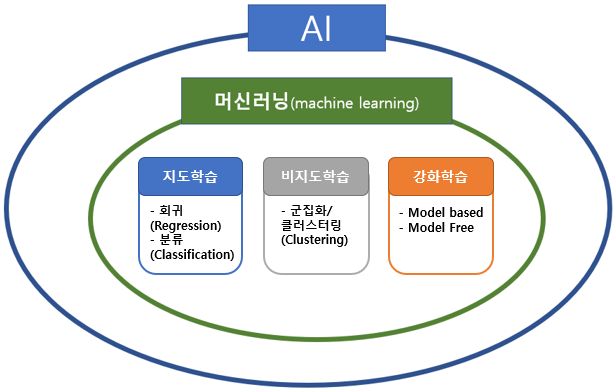

참조 : https://star7sss.tistory.com/410

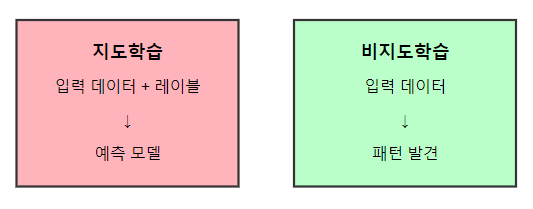

R에서 회귀 분석을 위해 사용할 수 있는 주요 패키지들을 사용하여 예제 위주로 배우게 됩니다.

- `stats`: R의 기본 패키지로, 선형 회귀를 위한 `lm()` 함수를 제공합니다.
- `glmnet`: 정규화된 일반화 선형 모델을 위한 패키지입니다.
- `randomForest`: 랜덤 포레스트 알고리즘을 구현한 패키지입니다.
- `rpart`: 결정 트리 알고리즘을 구현한 패키지입니다.
- `e1071`: 서포트 벡터 머신(SVM)을 포함한 여러 기계학습 알고리즘을 제공합니다.
- `class`: k-최근접 이웃(KNN) 알고리즘을 위한 패키지입니다.